# Looking at Food Webs

# Tabs

## Load Data

Setup:

```r
examples <- c(1, 34, 49, 86, 92, 33, 87)

# Check requisite packages are installed.
packages <- c(
  "plotly",
  "dplyr",
  "cheddar",
  "igraph",
  "expm",
  "foreach",
  "iterators",
  "rootSolve",
  "RMTRCode2"
)
for (pkg in packages) {
  library(pkg, character.only = TRUE)
}

# Reserved Names
communitiesAll <- NULL
invasionsDirected <- NULL
islandInteractionsOneEmptyTwo <- NULL
islandInteractionsOneEmptyTwoWhich <- NULL
islandInteractionsOneTwo <- NULL
islandInteractionsOneTwoWhich <- NULL
mats <- NULL
paramFrame <- NULL
plotScalingData <- NULL
pools <- NULL
```

Sanity Check:

```r
ellipsisApply <- function(..., FUN) {
  lapply(as.list(...), FUN)
}

load("LM1996-NumPoolCom-QOut-2021-05.RData")
# Stop if not all are not null
stopifnot(all(unlist(ellipsisApply(
  FUN = function(bool) {!is.null(bool)},
  communitiesAll,
  invasionsDirected,
  islandInteractionsOneEmptyTwo,
  islandInteractionsOneEmptyTwoWhich,
  islandInteractionsOneTwo,
  islandInteractionsOneTwoWhich,
  mats,
  paramFrame,
  plotScalingData,
  pools,
))))
```

Create graphs. Note the central issue here: the previous attempt at creating these graphs obeyed a ‘no-cannibalism’ rule due to how the `cheddar` package formats food webs. This is fine for trophic levels, but not so great for understanding mortality and growth in the system, as we are then limited to only exploitation as a source. For basal species, there is the positive reproduction/natural growth rate. For consumers, this is instead a loss due to maintenance requirements. Additionally, there is intra-specific competition (which `cheddar` thinks is cannibalism). For our full growth-mortality analysis, we need these in addition to the existing exploitation dynamics.

```r
foodWebs <- list()

for (r in 1:nrow(communitiesAll)) {
  foodWebs[[r]] <- with(
    communitiesAll[r, ],
    {
      redCom <- RMTRCode2::CsvRowSplit(Communities)
      redMat <- mats[[DatasetID]][[CombnNum]][redCom, redCom]
      redPool <- pools[[DatasetID]][[CombnNum]][redCom, ]

      colnames(redMat) <- paste0('s',as.character(redCom))
      rownames(redMat) <- colnames(redMat)

      names(redPool)[1] <- "node"
      redPool$node <- colnames(redMat)
      names(redPool)[3] <- "M"

      Graph <- igraph::graph_from_adjacency_matrix(
        redMat, weighted = TRUE
      )

      Graph <- igraph::set.vertex.attribute(
        Graph, "name", value = colnames(redMat)
      )

      redPool$N <- RMTRCode2::CsvRowSplit(CommunityAbund)

      # For later analysis, take the matrix diagonal.

      redPool$Intraspecific <- diag(redMat)

      GraphAsDataFrame <- igraph::as_data_frame(Graph)

      # Add in abundances for calculating abundance * (gain or loss)
      GraphAsDataFrame <- dplyr::left_join(
        GraphAsDataFrame,
        dplyr::select(redPool, node, N),
        by = c("to" = "node")
      )

      # Split data frame.
      ResCon <- GraphAsDataFrame[GraphAsDataFrame$weight > 0,]
      ConRes <- GraphAsDataFrame[GraphAsDataFrame$weight < 0,]

      # Reorder and rename variables.
      ResCon <- dplyr::select(ResCon,
                                 to, from, # resource = to, consumer = from,
                                 effectPerUnit = weight, resourceAbund = N)
      ConRes <- dplyr::select(ConRes,
                                 to, from, # resource = from, consumer = to,
                                 effectPerUnit = weight, consumerAbund = N)
      ResCon <- dplyr::mutate(dplyr::group_by(ResCon, from),
                              effectActual = effectPerUnit * resourceAbund,
                              Type = "Exploit+")
      ConRes <- dplyr::mutate(dplyr::group_by(ConRes, from),
                              effectActual = effectPerUnit * consumerAbund,
                              Type = ifelse(from == to,
                                            "SelfReg-",
                                            "Exploit-"))

      IntriG <- with(redPool, data.frame(
                              from = node, #resource = node,
                              to = node, #consumer = node,
                              effectPerUnit = ifelse(ReproductionRate > 0,
                                                   ReproductionRate, 0),
                              effectActual = ifelse(ReproductionRate > 0,
                                                  N * ReproductionRate, 0),
                              Type = "Intrisc+"))
      IntriL <- with(redPool, data.frame(
                              from = node, #resource = node,
                              to = node, #consumer = node,
                              effectPerUnit = ifelse(ReproductionRate < 0,
                                                   ReproductionRate, 0),
                              effectActual = ifelse(ReproductionRate < 0,
                                                  N * ReproductionRate, 0),
                              Type = "Intrisc-"))

      EdgeDataFrame <- dplyr::bind_rows(
        dplyr::select(ResCon, -resourceAbund),
        dplyr::select(ConRes, -consumerAbund),
        IntriG, IntriL
      )

      EdgeDataFrame <- EdgeDataFrame %>% dplyr::rename(
        # Empirically speaking, to and from appear reversed.
        # A consumer (from) should have a negative effect on resource (to),
        # but the organisation so far marks it as positive. We fix this.
        tempname = to,
        to = from
      ) %>% dplyr::rename(
        from = tempname
      ) %>% dplyr::filter(
        # Remove placeholder entries
        effectPerUnit != 0
      ) %>% dplyr::mutate(
        # Useful to keep effects separate
        effectSign = sign(effectPerUnit)
      ) %>% group_by(
        to, effectSign
      ) %>% dplyr::mutate(
        # Perform the post mortem of the most influential from's
        effectEfficiency = effectPerUnit / sum(effectPerUnit),
        effectNormalised = effectActual / sum(effectActual)
      ) %>% dplyr::arrange(to)

      list(
        Edges = EdgeDataFrame,
        Vertices = redPool
      )
    }
  )
}
```

Preparatory code:

```r
toCheddar <- function(EVList, name = "") {# Edges Vertices List
  links <- EVList$Edges

  # cheddar does not like "cannibalism".
  links <- links[
    links$to != links$from,
  ]

  # "[C]olumns called ‘resource’ and ‘consumer’ must be given."
  links <- dplyr::bind_rows(
    links %>% dplyr::filter(effectSign == 1) %>% dplyr::rename(
      resource = from, consumer = to),
    links %>% dplyr::filter(effectSign == -1) %>% dplyr::rename(
      resource = to, consumer = from),
  ) %>% dplyr::select(-Type) # Cheddar confuses node Type and edge Type.

  cheddar::Community(
    nodes = EVList$Vertices,
    properties = list(
      title = name,
      M.units = "masses",
      N.units = "abund"
    ),
    trophic.links = links
  )
}

toIGraph <- function(EVList, sign = 0) {
  igraph::graph_from_data_frame(
    d = if(sign == 0) {
      EVList$Edges
    } else {
      EVList$Edges[EVList$Edges$effectSign == sign, ]
    },
    directed = TRUE,
    vertices = EVList$Vertices
  )
}


toPostMortem <- function(EVList,
                         threshold = 0, # sets to minimal size edges below
                         nodeSize = c("None", "Abundance", "Size"),
                         edgeScale = 10,
                         reducedTrophic = TRUE) {
  if (tolower(threshold) == "adaptive") {
    threshold = EVList$Edges %>% group_by(
      to, effectSign
    ) %>% summarise(
      max = max(effectNormalised), .groups = "drop"
    ) %>% ungroup %>% pull(max) %>% min
  }

  theGc <- toCheddar(EVList, name = "Trophic Levels")
  theGi <- toIGraph(EVList)

  theGiGain <- toIGraph(EVList, sign = 1)
  theGiLoss <- toIGraph(EVList, sign = -1)

  theLayout <- igraph::layout.circle(theGi)

  theSize <- match.arg(nodeSize, c("Abundance", "Size", "None"))
  if (theSize == "Abundance")
    theVs <- sqrt(igraph::vertex_attr(theGi)$N) * 10
  else if (theSize == "Size") {
    theVs <- igraph::vertex_attr(theGi)$M
    theVs <- sqrt(theVs / min(theVs)) * 10
  } else if (theSize == "None") {
    theVs <- 15
  }

  theColors <- ifelse(
    igraph::vertex_attr(theGi)$Type == "Basal", "skyblue", "red"
  )
  if ("Core" %in% names(igraph::vertex_attr(theGi))) {
    theShapes <- ifelse(igraph::vertex_attr(theGi)$Core,
                        0,
                        1)
  } else {
    theShapes <- 1
    # Note Igraph uses "circle" then "rectangle",
    # but R and cheddar use "rectangle" then "circle", so we will use a !.
  }

  theBoth <- igraph::edge_attr(theGi)$effectNormalised
  theGain <- igraph::edge_attr(theGiGain)$effectNormalised
  theLoss <- igraph::edge_attr(theGiLoss)$effectNormalised

  theBoth[theBoth < threshold] <- 0
  theGain[theGain < threshold] <- 0
  theLoss[theLoss < threshold] <- 0

  # Inform the graphs of which edges are not needed.
  theGi <- igraph::delete_edges(theGi, which(theBoth == 0))
  theGiGain <- igraph::delete_edges(theGiGain, which(theGain == 0))
  theGiLoss <- igraph::delete_edges(theGiLoss, which(theLoss == 0))

  # Remove the same entries so that lengths match.
  theGain <- theGain[theGain > 0]
  theLoss <- theLoss[theLoss > 0]

  theGain <- theGain * edgeScale
  theLoss <- theLoss * edgeScale

  parold <- par(no.readonly = TRUE)
  par(mfrow = c(2, 2), # Two Rows, Two Columns
      mar = c(0, 1.5, 1, 0), # Margins, bottom, left, top, right
      oma = c(0.1, 0.1, 0.1, 0.1) # Outer margins.
  )

  cheddar::PlotWebByLevel(
    theGc,
    show.level.lines = TRUE,
    # Had been using LongWeighted, but that seems to give the upside down T.
    # Flow based seems to be more what we are expecting, given the usage of
    # thresholding and what that shows. The flows here are expected to be
    # flows of energy through the food web.
    level = cheddar::FlowBasedTrophicLevel(theGc, weight.by = "effectNormalised"),
      col = theColors,
      pch = theShapes
  )

  if (!reducedTrophic) {
    plot(
      theGi,
      layout = theLayout,
      vertex.size = theVs,
      edge.width = 1,
      edge.arrow.size = 0.3,
      edge.arrow.width = 1,
      vertex.color = theColors,
      vertex.shape = igraph::shapes()[as.numeric(!theShapes) + 1],
      edge.lty = 2,
      edge.color = "grey",
      edge.arrow.mode = ">",
      main = "Consumption"
    )
  } else {
    EVListRed <- EVList
    EVListRed$Edges <- EVListRed$Edges %>% dplyr::filter(
      effectNormalised >= threshold
    )
    theGc2 <- toCheddar(EVListRed, name = "Strongest Trophic Levels")
    cheddar::PlotWebByLevel(
      theGc2,
      show.level.lines = TRUE,
    level = cheddar::FlowBasedTrophicLevel(theGc2, weight.by = "effectNormalised"),
      col = theColors,
      pch = theShapes
    )
  }

  plot(
    theGiGain,
    layout = theLayout,
    vertex.size = theVs,
    edge.width = theGain,
    edge.arrow.size = 0.3,
    edge.arrow.width = 1,
    vertex.color = theColors,
      vertex.shape = igraph::shapes()[as.numeric(!theShapes) + 1],
    edge.lty = 2,
    edge.color = "blue",
    edge.arrow.mode = ">",
    main = "Consumer's Gains"
  )

  plot(
    theGiLoss,
    layout = theLayout,
    vertex.size = theVs,
    edge.width = theLoss,
    edge.arrow.size = 0.3,
    edge.arrow.width = 2,
    vertex.color = theColors,
      vertex.shape = igraph::shapes()[as.numeric(!theShapes) + 1],
    edge.lty = 3,
    edge.color = "darkred",
    edge.arrow.mode = "<",
    main = "Resource's Losses"
  )

  par(parold)

  EVList$Edges %>% dplyr::ungroup() %>% dplyr::filter(
    effectNormalised >= threshold
  ) %>% dplyr::select(
    -effectSign
  ) %>% dplyr::arrange(
    to, -effectNormalised
  )
}
```

### Reading the plots:

First, I note that we have multiple threshold values used. Each set of plots is generated with a threshold value culling the least important edges. Because of the way I have divided the edges, e.g. one edge for the resource-on-consumer effects and one edge for the consumer-on-resource effects, interactions that are important in only one direction have that direction preserved. To cull the least important edges, I multiply the interaction effect by the abundance of the species performing the interaction. I then normalise amongst all edges grouped by destination and sign (positive/negative), edge effect divided by sum of edge effects, and remove those that do not exceed the threshold.

Top-left: trophic levels if we consider every interaction that is observed. This results in a size-structured “radio tower”, with basal species on the bottom and consumers increasing in size feeding on each other and those beneath them.

Bottom-left: graph/network of most important positive flows in the system. Blue nodes/circles represent basal species. Red nodes represent consumers. Thicker arrows represent more important flows/heavier weights. The “hooks” on each basal species indicate the intrinsic growth rates of those species. (Recall that they are normalised, hence the equal sizes.) This can be used to trace the consumers’ diets and what species are most important to feeding the higher trophic levels.

Bottom-right: graph/network of most important negative flows in the system. Description is as above, but the “hooks” on the consumer species now represent negative intrinsic growth rates, and “hooks” on basal species represent intra-specific competition. This plot can be used to see how consumers are regulated and regulate their environment.

## Discussion

### Example LM 1

This is a nice, simple graph to start with. There are effectively two subsystems: the s2 - s12 relationship and the s4, s6 - s29 relationships. There is a small amount of significant feeding of s29 on s2 and a small amount of self regulation by s6, but the system appears to predominantly be two standard, separate Lotka-Volterra systems otherwise.

### Hybrid

This system is the result of two communities dispersing into the empty third community, decoupling, and then allowing the community to collapse until it finds a steady state. This found steady state does persist, but is not uninvadable (and thus was not found via assembly).

At the highest level threshold I show, there is a slight anomaly: there is a node in the tropbic level plot that appears to have no connections. Despite appearing in the basal layer, this node is consumer s351, which consumes 6 species (5 basal) at above the $5\%$ threshold with none of the species amounting to more than $30\%$ of its diet. (The highest is $29.3\%$, so it is not too far off.) This species is not heavily involved in regulating the other species as a result. Instead, this role is fulfilled primarily by s339, which consumes 6 species (again, 5 basal). Species s339 has a similar diet to s351, but a more potent effect on the actual amount of the resource lost. (Species s339 has nearly three times the abundance of s351.) Worth noting is the almost parasitic s350 (which does not appear to regulate anything other than itself at high levels) which otherwise derives benefit from the system that s331 regulates.

### Largest Assembled

The largest assembled system that we have from a pool that produced at least two such communities has 17 nodes. (The other had 13.) Despite higher numbers of interactions, it appears that s270 is the basal responsible for 3 consumers, s439 is responsible for another two, and s546 shares with one of the s270 consumers. The diets do not seem to greatly expand as the number of nodes increases. Instead, the increased number of basal species appears to result in more top-down regulation. Lowering the threshold to 0.2 from 0.3 has s546 support all three of s270’s consumers. Even at the lowest threshold of 0.05, 5 of the basal species do not appear to support the consumers and are instead merely regulated by them.

### Largest Hybrid

Much of what appears true about the largest assembled system appears to be true about the largest hybrid (22 species). Noting that the largest hybrid is uninvadable but does not persist on its own, we can observe the following. First, most consumers primarily consume around one or two species which are basals in this instance. Second, they regulate more species than they consume by a fair margin. Third, none of the basal species self-regulate at greater than 0.1 levels. Fourth, most of the regulation of consumers is by the intrinsic negative growth rate. Fifth, like the other “does not persist” case, some of the consumers appear to not self regulate to large quantities, perhaps suggesting a common reason as to the collapse of the system.

## Threshold = 0.05

```r
thresholdEdges <- 0.05
```

### Example LM 1

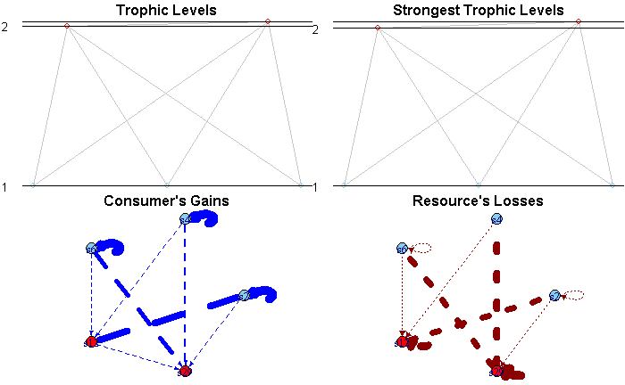

```r
toPostMortem(foodWebs[[examples[1]]], nodeSize = "None", threshold = thresholdEdges) -> temp
```

```r
temp
```

| from | to | effectPerUnit | effectActual | Type | effectEfficiency | effectNormalised |
| --- | --- | --- | --- | --- | --- | --- |
| s12 | s12 | -1.066330e-01 | -2.154863675 | Intrisc- | 0.949973409 | 0.95315714 |
| s2 | s12 | 2.084357e-04 | 0.154843848 | Exploit+ | 0.484174484 | 0.85746787 |
| s6 | s12 | 9.620333e-05 | 0.015597292 | Exploit+ | 0.223470375 | 0.08637203 |
| s4 | s12 | 1.258580e-04 | 0.010141543 | Exploit+ | 0.292355141 | 0.05616011 |
| s2 | s2 | 3.082794e-01 | 229.016318271 | Intrisc+ | 1.000000000 | 1.00000000 |
| s12 | s2 | -9.807071e-03 | -0.198183448 | Exploit- | 0.770277895 | 0.71180468 |
| s29 | s2 | -2.890148e-03 | -0.054505145 | Exploit- | 0.227001184 | 0.19576315 |
| s2 | s2 | -3.464238e-05 | -0.025735326 | SelfReg- | 0.002720921 | 0.09243217 |
| s29 | s29 | -9.427165e-02 | -1.777864268 | Intrisc- | 1.000000000 | 1.00000000 |
| s6 | s29 | 2.605935e-04 | 0.042249610 | Exploit+ | 0.306503375 | 0.51192265 |

[output cut: 10 more lines]

### Example LM 2

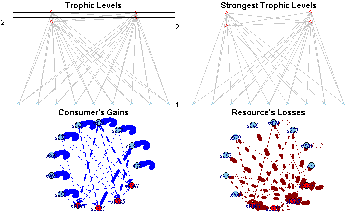

```r
toPostMortem(foodWebs[[examples[2]]], nodeSize = "None", threshold = thresholdEdges) -> temp
```

```r
temp
```

| from | to | effectPerUnit | effectActual | Type | effectEfficiency | effectNormalised |
| --- | --- | --- | --- | --- | --- | --- |
| s1063 | s1063 | -6.838267e-02 | -0.666490934 | Intrisc- | 1.000000000 | 1.00000000 |
| s439 | s1063 | 2.293504e-04 | 0.024780393 | Exploit+ | 0.131511831 | 0.36237829 |
| s397 | s1063 | 2.933916e-04 | 0.009568852 | Exploit+ | 0.168233713 | 0.13993096 |
| s1535 | s1063 | 1.504418e-04 | 0.008584156 | Exploit+ | 0.086264835 | 0.12553116 |
| s270 | s1063 | 1.233981e-05 | 0.007939722 | Exploit+ | 0.007075773 | 0.11610723 |
| s579 | s1063 | 2.624208e-04 | 0.007865072 | Exploit+ | 0.150474721 | 0.11501558 |
| s966 | s1063 | 2.201035e-04 | 0.005460390 | Exploit+ | 0.126209576 | 0.07985050 |
| s270 | s1335 | 2.284462e-04 | 0.146987603 | Exploit+ | 0.218565040 | 0.65115783 |
| s1535 | s1335 | -1.392633e-03 | -0.079463160 | Exploit- | 0.013753356 | 0.38204917 |
| s1335 | s1335 | -9.117707e-02 | -0.073436363 | Intrisc- | 0.900445918 | 0.35307306 |

[output cut: 51 more lines]

### Invadable

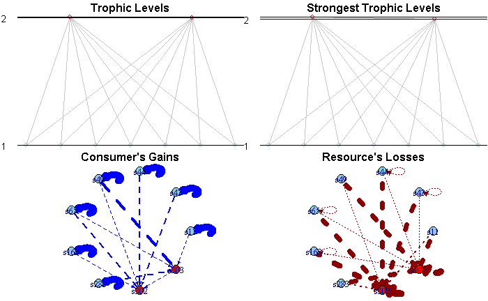

```r
toPostMortem(foodWebs[[examples[3]]], nodeSize = "None", threshold = thresholdEdges) -> temp
```

```r
temp
```

| from | to | effectPerUnit | effectActual | Type | effectEfficiency | effectNormalised |
| --- | --- | --- | --- | --- | --- | --- |
| s11 | s11 | 3.391763e-01 | 58.903454261 | Intrisc+ | 1.00000000 | 1.00000000 |
| s303 | s11 | -8.424589e-03 | -0.243872940 | Exploit- | 0.72018404 | 0.76475029 |
| s302 | s11 | -3.241539e-03 | -0.069514158 | Exploit- | 0.27710609 | 0.21798635 |
| s163 | s163 | 1.883789e-01 | 6.103189874 | Intrisc+ | 1.00000000 | 1.00000000 |
| s302 | s163 | -4.302441e-03 | -0.092264979 | Exploit- | 0.88827817 | 0.85015850 |
| s303 | s163 | -3.680580e-04 | -0.010654452 | Exploit- | 0.07598892 | 0.09817347 |
| s163 | s163 | -1.730750e-04 | -0.005607366 | SelfReg- | 0.03573291 | 0.05166803 |
| s283 | s283 | 3.307972e-01 | 81.788910262 | Intrisc+ | 1.00000000 | 1.00000000 |
| s303 | s283 | -8.051737e-03 | -0.233079718 | Exploit- | 0.71505722 | 0.75460571 |
| s302 | s283 | -3.177576e-03 | -0.068142472 | Exploit- | 0.28219358 | 0.22061421 |

[output cut: 27 more lines]

### Does Not Persist

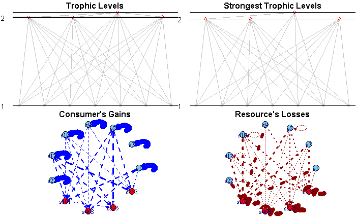

```r
toPostMortem(foodWebs[[examples[4]]], nodeSize = "None", threshold = thresholdEdges) -> temp
```

```r
temp
```

| from | to | effectPerUnit | effectActual | Type | effectEfficiency | effectNormalised |
| --- | --- | --- | --- | --- | --- | --- |
| s1 | s1 | 2.725840e-01 | 62.823038712 | Intrisc+ | 1.000000000 | 1.00000000 |
| s101 | s1 | -8.772184e-03 | -0.180708778 | Exploit- | 0.374763817 | 0.66314729 |
| s563 | s1 | -5.397854e-03 | -0.048762014 | Exploit- | 0.230606239 | 0.17894204 |
| s463 | s1 | -7.865650e-03 | -0.029617907 | Exploit- | 0.336035029 | 0.10868888 |
| s10 | s10 | 1.839407e-01 | 11.242213290 | Intrisc+ | 1.000000000 | 1.00000000 |
| s101 | s10 | -3.622470e-03 | -0.074623624 | Exploit- | 0.158915375 | 0.40568017 |
| s563 | s10 | -5.079242e-03 | -0.045883805 | Exploit- | 0.222822999 | 0.24944044 |
| s525 | s10 | -9.435170e-03 | -0.036337967 | Exploit- | 0.413914655 | 0.19754592 |
| s463 | s10 | -4.491367e-03 | -0.016912127 | Exploit- | 0.197033286 | 0.09194025 |
| s10 | s10 | -1.667152e-04 | -0.010189413 | SelfReg- | 0.007313686 | 0.05539322 |

[output cut: 48 more lines]

### Hybrid

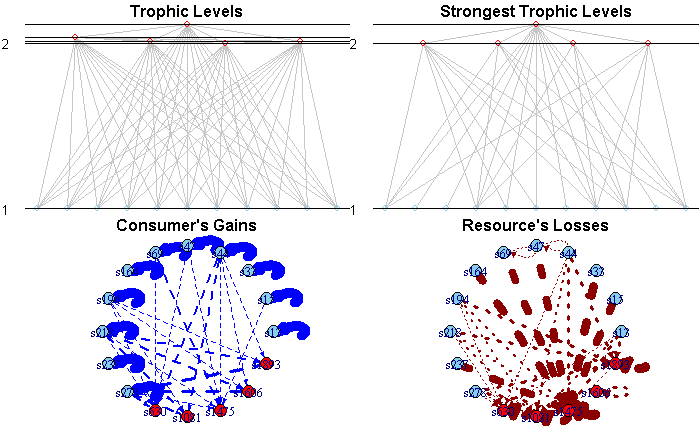

```r
toPostMortem(foodWebs[[examples[5]]], nodeSize = "None", threshold = thresholdEdges) -> temp
```

```r
temp
```

| from | to | effectPerUnit | effectActual | Type | effectEfficiency | effectNormalised |
| --- | --- | --- | --- | --- | --- | --- |
| s1081 | s1081 | -9.067629e-02 | -0.693701927 | Intrisc- | 0.969699358 | 0.89476166 |
| s218 | s1081 | 1.588236e-04 | 0.042768085 | Exploit+ | 0.117834769 | 0.24826658 |
| s278 | s1081 | 1.337197e-04 | 0.040661113 | Exploit+ | 0.099209684 | 0.23603572 |
| s44 | s1081 | 1.773059e-04 | 0.040360109 | Exploit+ | 0.131547229 | 0.23428840 |
| s194 | s1081 | 1.789582e-04 | 0.030626409 | Exploit+ | 0.132773151 | 0.17778476 |
| s1475 | s1081 | -2.414921e-03 | -0.080006635 | Exploit- | 0.025825353 | 0.10319543 |
| s13 | s13 | 3.521072e-01 | 3.030224005 | Intrisc+ | 1.000000000 | 1.00000000 |
| s1893 | s13 | -1.036299e-02 | -0.136775744 | Exploit- | 0.250026274 | 0.38844912 |
| s1475 | s13 | -3.229121e-03 | -0.106981176 | Exploit- | 0.077908505 | 0.30383124 |
| s1081 | s13 | -9.574350e-03 | -0.073246759 | Exploit- | 0.230998875 | 0.20802401 |

[output cut: 62 more lines]

### Largest Assembled

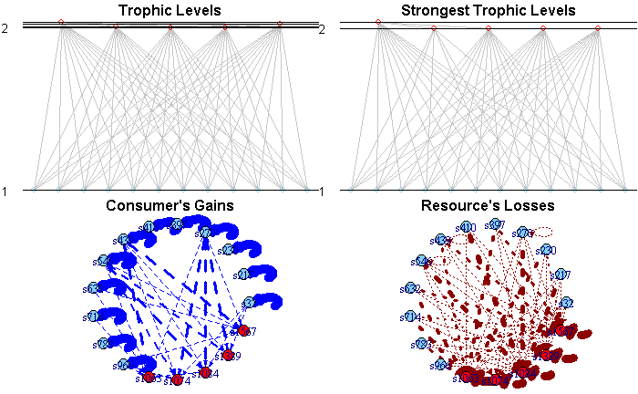

```r
toPostMortem(foodWebs[[examples[6]]], nodeSize = "None", threshold = thresholdEdges) -> temp
```

```r
temp
```

| from | to | effectPerUnit | effectActual | Type | effectEfficiency | effectNormalised |
| --- | --- | --- | --- | --- | --- | --- |
| s1063 | s1063 | -6.838267e-02 | -0.919470115 | Intrisc- | 1.000000000 | 1.00000000 |
| s439 | s1063 | 2.293504e-04 | 0.022345909 | Exploit+ | 0.095650288 | 0.32677739 |
| s632 | s1063 | 2.683978e-04 | 0.009043298 | Exploit+ | 0.111934967 | 0.13224548 |
| s966 | s1063 | 2.201035e-04 | 0.007277659 | Exploit+ | 0.091793888 | 0.10642549 |
| s270 | s1063 | 1.233981e-05 | 0.006045527 | Exploit+ | 0.005146303 | 0.08840729 |
| s1084 | s1063 | 1.761510e-04 | 0.004748683 | Exploit+ | 0.073463553 | 0.06944278 |
| s546 | s1063 | 9.330815e-06 | 0.004628226 | Exploit+ | 0.003891404 | 0.06768127 |
| s714 | s1063 | 2.841223e-04 | 0.003949026 | Exploit+ | 0.118492852 | 0.05774894 |
| s1074 | s1074 | -8.841746e-02 | -0.291192362 | Intrisc- | 0.977822227 | 0.91250917 |
| s270 | s1074 | 7.367649e-05 | 0.036095624 | Exploit+ | 0.043229834 | 0.31026830 |

[output cut: 88 more lines]

### Largest Hybrid

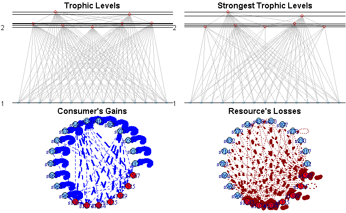

```r
toPostMortem(foodWebs[[examples[7]]], nodeSize = "None", threshold = thresholdEdges) -> temp
```

```r
temp
```

| from | to | effectPerUnit | effectActual | Type | effectEfficiency | effectNormalised |
| --- | --- | --- | --- | --- | --- | --- |
| s1063 | s1063 | -6.838267e-02 | -9.182781e-01 | Intrisc- | 1.0000000000 | 1.00000000 |
| s439 | s1063 | 2.293504e-04 | 2.235780e-02 | Exploit+ | 0.0692485098 | 0.32694304 |
| s632 | s1063 | 2.683978e-04 | 9.029502e-03 | Exploit+ | 0.0810382257 | 0.13204041 |
| s966 | s1063 | 2.201035e-04 | 7.277139e-03 | Exploit+ | 0.0664565689 | 0.10641522 |
| s270 | s1063 | 1.233981e-05 | 6.056640e-03 | Exploit+ | 0.0037257995 | 0.08856760 |
| s1084 | s1063 | 1.761510e-04 | 4.734274e-03 | Exploit+ | 0.0531858466 | 0.06923035 |
| s546 | s1063 | 9.330815e-06 | 4.644987e-03 | Exploit+ | 0.0028172833 | 0.06792468 |
| s714 | s1063 | 2.841223e-04 | 3.841191e-03 | Exploit+ | 0.0857859769 | 0.05617059 |
| s1074 | s1074 | -8.841746e-02 | -2.875985e-01 | Intrisc- | 0.9760812353 | 0.91155074 |
| s270 | s1074 | 7.367649e-05 | 3.616198e-02 | Exploit+ | 0.0320703153 | 0.31094776 |

[output cut: 119 more lines]

## Threshold = 0.1

```r
thresholdEdges <- 0.1
```

### Example LM 1

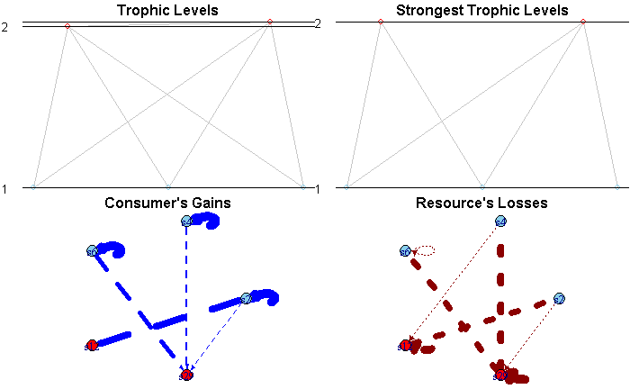

```r
toPostMortem(foodWebs[[examples[1]]], nodeSize = "None", threshold = thresholdEdges) -> temp
```

```r
temp
```

| from | to | effectPerUnit | effectActual | Type | effectEfficiency | effectNormalised |
| --- | --- | --- | --- | --- | --- | --- |
| s12 | s12 | -1.066330e-01 | -2.15486367 | Intrisc- | 0.94997341 | 0.9531571 |
| s2 | s12 | 2.084357e-04 | 0.15484385 | Exploit+ | 0.48417448 | 0.8574679 |
| s2 | s2 | 3.082794e-01 | 229.01631827 | Intrisc+ | 1.00000000 | 1.0000000 |
| s12 | s2 | -9.807071e-03 | -0.19818345 | Exploit- | 0.77027790 | 0.7118047 |
| s29 | s2 | -2.890148e-03 | -0.05450514 | Exploit- | 0.22700118 | 0.1957632 |
| s29 | s29 | -9.427165e-02 | -1.77786427 | Intrisc- | 1.00000000 | 1.0000000 |
| s6 | s29 | 2.605935e-04 | 0.04224961 | Exploit+ | 0.30650338 | 0.5119227 |
| s4 | s29 | 2.738435e-04 | 0.02206610 | Exploit+ | 0.32208770 | 0.2673667 |
| s2 | s29 | 1.637554e-05 | 0.01216515 | Exploit+ | 0.01926049 | 0.1474006 |
| s4 | s4 | 2.118144e-01 | 17.06783849 | Intrisc+ | 1.00000000 | 1.0000000 |

[output cut: 5 more lines]

### Example LM 2

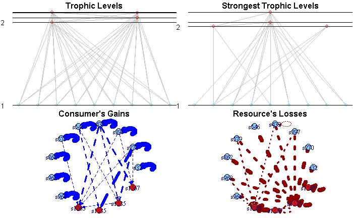

```r
toPostMortem(foodWebs[[examples[2]]], nodeSize = "None", threshold = thresholdEdges) -> temp
```

```r
temp
```

| from | to | effectPerUnit | effectActual | Type | effectEfficiency | effectNormalised |
| --- | --- | --- | --- | --- | --- | --- |
| s1063 | s1063 | -6.838267e-02 | -0.666490934 | Intrisc- | 1.000000000 | 1.0000000 |
| s439 | s1063 | 2.293504e-04 | 0.024780393 | Exploit+ | 0.131511831 | 0.3623783 |
| s397 | s1063 | 2.933916e-04 | 0.009568852 | Exploit+ | 0.168233713 | 0.1399310 |
| s1535 | s1063 | 1.504418e-04 | 0.008584156 | Exploit+ | 0.086264835 | 0.1255312 |
| s270 | s1063 | 1.233981e-05 | 0.007939722 | Exploit+ | 0.007075773 | 0.1161072 |
| s579 | s1063 | 2.624208e-04 | 0.007865072 | Exploit+ | 0.150474721 | 0.1150156 |
| s270 | s1335 | 2.284462e-04 | 0.146987603 | Exploit+ | 0.218565040 | 0.6511578 |
| s1535 | s1335 | -1.392633e-03 | -0.079463160 | Exploit- | 0.013753356 | 0.3820492 |
| s1335 | s1335 | -9.117707e-02 | -0.073436363 | Intrisc- | 0.900445918 | 0.3530731 |
| s546 | s1335 | 1.732096e-04 | 0.052277054 | Exploit+ | 0.165717661 | 0.2315883 |

[output cut: 33 more lines]

### Invadable

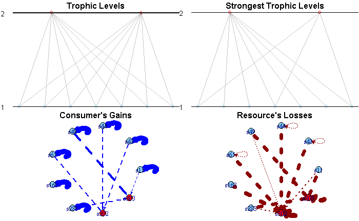

```r
toPostMortem(foodWebs[[examples[3]]], nodeSize = "None", threshold = thresholdEdges) -> temp
```

```r
temp
```

| from | to | effectPerUnit | effectActual | Type | effectEfficiency | effectNormalised |
| --- | --- | --- | --- | --- | --- | --- |
| s11 | s11 | 0.3391763332 | 58.90345426 | Intrisc+ | 1.00000000 | 1.0000000 |
| s303 | s11 | -0.0084245888 | -0.24387294 | Exploit- | 0.72018404 | 0.7647503 |
| s302 | s11 | -0.0032415393 | -0.06951416 | Exploit- | 0.27710609 | 0.2179864 |
| s163 | s163 | 0.1883788831 | 6.10318987 | Intrisc+ | 1.00000000 | 1.0000000 |
| s302 | s163 | -0.0043024409 | -0.09226498 | Exploit- | 0.88827817 | 0.8501585 |
| s283 | s283 | 0.3307971683 | 81.78891026 | Intrisc+ | 1.00000000 | 1.0000000 |
| s303 | s283 | -0.0080517370 | -0.23307972 | Exploit- | 0.71505722 | 0.7546057 |
| s302 | s283 | -0.0031775758 | -0.06814247 | Exploit- | 0.28219358 | 0.2206142 |
| s302 | s302 | -0.0836685802 | -1.79425584 | Intrisc- | 1.00000000 | 1.0000000 |
| s44 | s302 | 0.0002454122 | 0.03094582 | Exploit+ | 0.20200672 | 0.2698202 |

[output cut: 18 more lines]

### Does Not Persist

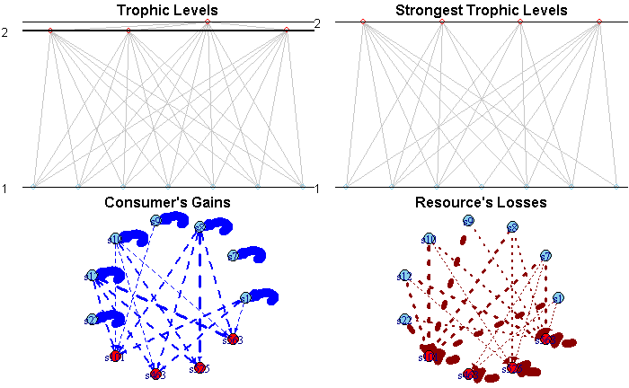

```r
toPostMortem(foodWebs[[examples[4]]], nodeSize = "None", threshold = thresholdEdges) -> temp
```

```r
temp
```

| from | to | effectPerUnit | effectActual | Type | effectEfficiency | effectNormalised |
| --- | --- | --- | --- | --- | --- | --- |
| s1 | s1 | 2.725840e-01 | 62.823038712 | Intrisc+ | 1.00000000 | 1.0000000 |
| s101 | s1 | -8.772184e-03 | -0.180708778 | Exploit- | 0.37476382 | 0.6631473 |
| s563 | s1 | -5.397854e-03 | -0.048762014 | Exploit- | 0.23060624 | 0.1789420 |
| s463 | s1 | -7.865650e-03 | -0.029617907 | Exploit- | 0.33603503 | 0.1086889 |
| s10 | s10 | 1.839407e-01 | 11.242213290 | Intrisc+ | 1.00000000 | 1.0000000 |
| s101 | s10 | -3.622470e-03 | -0.074623624 | Exploit- | 0.15891537 | 0.4056802 |
| s563 | s10 | -5.079242e-03 | -0.045883805 | Exploit- | 0.22282300 | 0.2494404 |
| s525 | s10 | -9.435170e-03 | -0.036337967 | Exploit- | 0.41391465 | 0.1975459 |
| s101 | s101 | -7.739102e-02 | -1.594270688 | Intrisc- | 0.95508761 | 0.9894034 |
| s1 | s101 | 1.043120e-04 | 0.024041026 | Exploit+ | 0.07812004 | 0.2542893 |

[output cut: 37 more lines]

### Hybrid

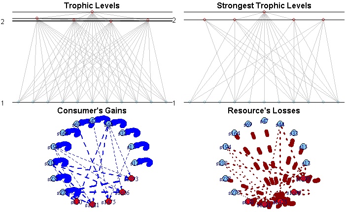

```r
toPostMortem(foodWebs[[examples[5]]], nodeSize = "None", threshold = thresholdEdges) -> temp
```

```r
temp
```

| from | to | effectPerUnit | effectActual | Type | effectEfficiency | effectNormalised |
| --- | --- | --- | --- | --- | --- | --- |
| s1081 | s1081 | -9.067629e-02 | -0.69370193 | Intrisc- | 0.96969936 | 0.8947617 |
| s218 | s1081 | 1.588236e-04 | 0.04276809 | Exploit+ | 0.11783477 | 0.2482666 |
| s278 | s1081 | 1.337197e-04 | 0.04066111 | Exploit+ | 0.09920968 | 0.2360357 |
| s44 | s1081 | 1.773059e-04 | 0.04036011 | Exploit+ | 0.13154723 | 0.2342884 |
| s194 | s1081 | 1.789582e-04 | 0.03062641 | Exploit+ | 0.13277315 | 0.1777848 |
| s1475 | s1081 | -2.414921e-03 | -0.08000663 | Exploit- | 0.02582535 | 0.1031954 |
| s13 | s13 | 3.521072e-01 | 3.03022400 | Intrisc+ | 1.00000000 | 1.0000000 |
| s1893 | s13 | -1.036299e-02 | -0.13677574 | Exploit- | 0.25002627 | 0.3884491 |
| s1475 | s13 | -3.229121e-03 | -0.10698118 | Exploit- | 0.07790850 | 0.3038312 |
| s1081 | s13 | -9.574350e-03 | -0.07324676 | Exploit- | 0.23099888 | 0.2080240 |

[output cut: 48 more lines]

### Largest Assembled

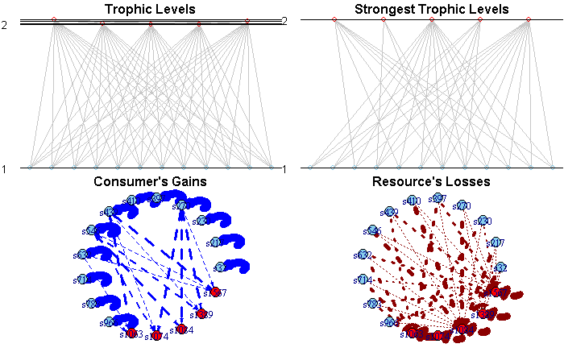

```r
toPostMortem(foodWebs[[examples[6]]], nodeSize = "None", threshold = thresholdEdges) -> temp
```

```r
temp
```

| from | to | effectPerUnit | effectActual | Type | effectEfficiency | effectNormalised |
| --- | --- | --- | --- | --- | --- | --- |
| s1063 | s1063 | -6.838267e-02 | -0.919470115 | Intrisc- | 1.000000000 | 1.0000000 |
| s439 | s1063 | 2.293504e-04 | 0.022345909 | Exploit+ | 0.095650288 | 0.3267774 |
| s632 | s1063 | 2.683978e-04 | 0.009043298 | Exploit+ | 0.111934967 | 0.1322455 |
| s966 | s1063 | 2.201035e-04 | 0.007277659 | Exploit+ | 0.091793888 | 0.1064255 |
| s1074 | s1074 | -8.841746e-02 | -0.291192362 | Intrisc- | 0.977822227 | 0.9125092 |
| s270 | s1074 | 7.367649e-05 | 0.036095624 | Exploit+ | 0.043229834 | 0.3102683 |
| s546 | s1074 | 6.303019e-05 | 0.031263932 | Exploit+ | 0.036983096 | 0.2687364 |
| s439 | s1074 | 2.001920e-04 | 0.019504972 | Exploit+ | 0.117463088 | 0.1676595 |
| s1084 | s1084 | -7.518463e-02 | -2.026829001 | Intrisc- | 0.944682769 | 0.9737787 |
| s546 | s1084 | 1.037928e-04 | 0.051482814 | Exploit+ | 0.081237065 | 0.3967486 |

[output cut: 58 more lines]

### Largest Hybrid

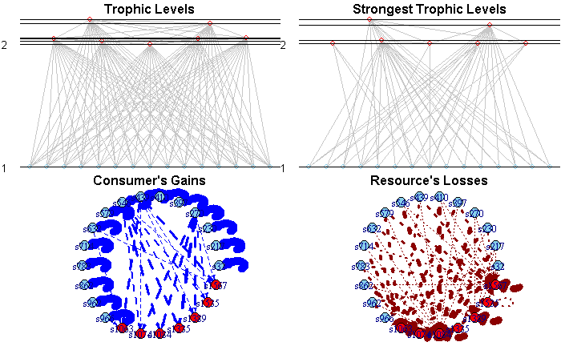

```r
toPostMortem(foodWebs[[examples[7]]], nodeSize = "None", threshold = thresholdEdges) -> temp
```

```r
temp
```

| from | to | effectPerUnit | effectActual | Type | effectEfficiency | effectNormalised |
| --- | --- | --- | --- | --- | --- | --- |
| s1063 | s1063 | -6.838267e-02 | -9.182781e-01 | Intrisc- | 1.000000000 | 1.0000000 |
| s439 | s1063 | 2.293504e-04 | 2.235780e-02 | Exploit+ | 0.069248510 | 0.3269430 |
| s632 | s1063 | 2.683978e-04 | 9.029502e-03 | Exploit+ | 0.081038226 | 0.1320404 |
| s966 | s1063 | 2.201035e-04 | 7.277139e-03 | Exploit+ | 0.066456569 | 0.1064152 |
| s1074 | s1074 | -8.841746e-02 | -2.875985e-01 | Intrisc- | 0.976081235 | 0.9115507 |
| s270 | s1074 | 7.367649e-05 | 3.616198e-02 | Exploit+ | 0.032070315 | 0.3109478 |
| s546 | s1074 | 6.303019e-05 | 3.137716e-02 | Exploit+ | 0.027436135 | 0.2698043 |
| s439 | s1074 | 2.001920e-04 | 1.951535e-02 | Exploit+ | 0.087140707 | 0.1678076 |
| s1084 | s1084 | -7.518463e-02 | -2.020679e+00 | Intrisc- | 0.939554994 | 0.9737069 |
| s546 | s1084 | 1.037928e-04 | 5.166927e-02 | Exploit+ | 0.061614060 | 0.3982049 |

[output cut: 81 more lines]

## Threshold = 0.2

```r
thresholdEdges <- 0.2
```

### Example LM 1

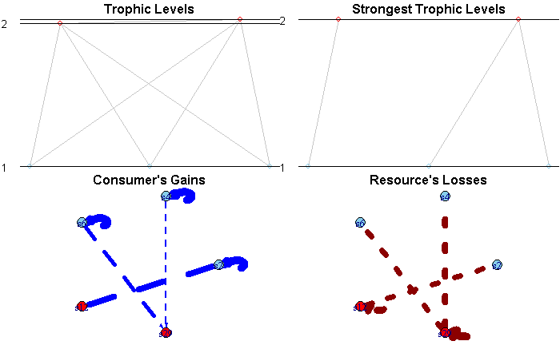

```r
toPostMortem(foodWebs[[examples[1]]], nodeSize = "None", threshold = thresholdEdges) -> temp
```

```r
temp
```

| from | to | effectPerUnit | effectActual | Type | effectEfficiency | effectNormalised |
| --- | --- | --- | --- | --- | --- | --- |
| s12 | s12 | -0.1066330280 | -2.15486367 | Intrisc- | 0.9499734 | 0.9531571 |
| s2 | s12 | 0.0002084357 | 0.15484385 | Exploit+ | 0.4841745 | 0.8574679 |
| s2 | s2 | 0.3082794145 | 229.01631827 | Intrisc+ | 1.0000000 | 1.0000000 |
| s12 | s2 | -0.0098070710 | -0.19818345 | Exploit- | 0.7702779 | 0.7118047 |
| s29 | s29 | -0.0942716513 | -1.77786427 | Intrisc- | 1.0000000 | 1.0000000 |
| s6 | s29 | 0.0002605935 | 0.04224961 | Exploit+ | 0.3065034 | 0.5119227 |
| s4 | s29 | 0.0002738435 | 0.02206610 | Exploit+ | 0.3220877 | 0.2673667 |
| s4 | s4 | 0.2118143576 | 17.06783849 | Intrisc+ | 1.0000000 | 1.0000000 |
| s29 | s4 | -0.0088792340 | -0.16745302 | Exploit- | 0.8804370 | 0.8417415 |
| s6 | s6 | 0.2135749758 | 34.62656907 | Intrisc+ | 1.0000000 | 1.0000000 |

[output cut: 1 more lines]

### Example LM 2

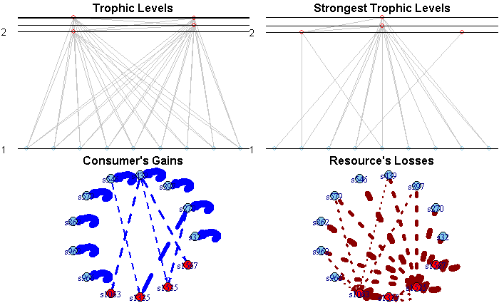

```r
toPostMortem(foodWebs[[examples[2]]], nodeSize = "None", threshold = thresholdEdges) -> temp
```

```r
temp
```

| from | to | effectPerUnit | effectActual | Type | effectEfficiency | effectNormalised |
| --- | --- | --- | --- | --- | --- | --- |
| s1063 | s1063 | -6.838267e-02 | -0.66649093 | Intrisc- | 1.00000000 | 1.0000000 |
| s439 | s1063 | 2.293504e-04 | 0.02478039 | Exploit+ | 0.13151183 | 0.3623783 |
| s270 | s1335 | 2.284462e-04 | 0.14698760 | Exploit+ | 0.21856504 | 0.6511578 |
| s1535 | s1335 | -1.392633e-03 | -0.07946316 | Exploit- | 0.01375336 | 0.3820492 |
| s1335 | s1335 | -9.117707e-02 | -0.07343636 | Intrisc- | 0.90044592 | 0.3530731 |
| s546 | s1335 | 1.732096e-04 | 0.05227705 | Exploit+ | 0.16571766 | 0.2315883 |
| s1063 | s1335 | -4.438857e-03 | -0.04326327 | Exploit- | 0.04383723 | 0.2080045 |
| s1535 | s1535 | -7.190290e-02 | -4.10275449 | Intrisc- | 0.97083024 | 0.9961165 |
| s270 | s1535 | 5.113308e-05 | 0.03290021 | Exploit+ | 0.04282004 | 0.3743002 |
| s439 | s1535 | 1.856612e-04 | 0.02005996 | Exploit+ | 0.15547706 | 0.2282187 |

[output cut: 25 more lines]

### Invadable

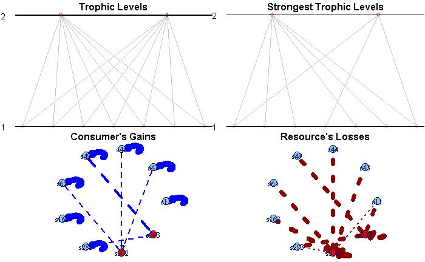

```r
toPostMortem(foodWebs[[examples[3]]], nodeSize = "None", threshold = thresholdEdges) -> temp
```

```r
temp
```

| from | to | effectPerUnit | effectActual | Type | effectEfficiency | effectNormalised |
| --- | --- | --- | --- | --- | --- | --- |
| s11 | s11 | 0.3391763332 | 58.90345426 | Intrisc+ | 1.0000000 | 1.0000000 |
| s303 | s11 | -0.0084245888 | -0.24387294 | Exploit- | 0.7201840 | 0.7647503 |
| s302 | s11 | -0.0032415393 | -0.06951416 | Exploit- | 0.2771061 | 0.2179864 |
| s163 | s163 | 0.1883788831 | 6.10318987 | Intrisc+ | 1.0000000 | 1.0000000 |
| s302 | s163 | -0.0043024409 | -0.09226498 | Exploit- | 0.8882782 | 0.8501585 |
| s283 | s283 | 0.3307971683 | 81.78891026 | Intrisc+ | 1.0000000 | 1.0000000 |
| s303 | s283 | -0.0080517370 | -0.23307972 | Exploit- | 0.7150572 | 0.7546057 |
| s302 | s283 | -0.0031775758 | -0.06814247 | Exploit- | 0.2821936 | 0.2206142 |
| s302 | s302 | -0.0836685802 | -1.79425584 | Intrisc- | 1.0000000 | 1.0000000 |
| s44 | s302 | 0.0002454122 | 0.03094582 | Exploit+ | 0.2020067 | 0.2698202 |

[output cut: 13 more lines]

### Does Not Persist

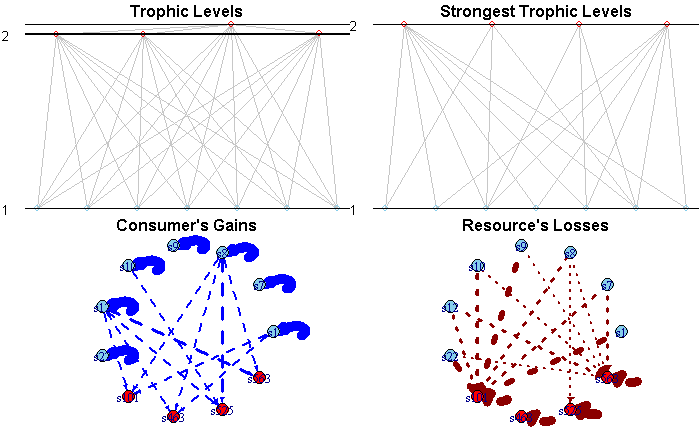

```r
toPostMortem(foodWebs[[examples[4]]], nodeSize = "None", threshold = thresholdEdges) -> temp
```

```r
temp
```

| from | to | effectPerUnit | effectActual | Type | effectEfficiency | effectNormalised |
| --- | --- | --- | --- | --- | --- | --- |
| s1 | s1 | 2.725840e-01 | 62.82303871 | Intrisc+ | 1.00000000 | 1.0000000 |
| s101 | s1 | -8.772184e-03 | -0.18070878 | Exploit- | 0.37476382 | 0.6631473 |
| s10 | s10 | 1.839407e-01 | 11.24221329 | Intrisc+ | 1.00000000 | 1.0000000 |
| s101 | s10 | -3.622470e-03 | -0.07462362 | Exploit- | 0.15891537 | 0.4056802 |
| s563 | s10 | -5.079242e-03 | -0.04588380 | Exploit- | 0.22282300 | 0.2494404 |
| s101 | s101 | -7.739102e-02 | -1.59427069 | Intrisc- | 0.95508761 | 0.9894034 |
| s1 | s101 | 1.043120e-04 | 0.02404103 | Exploit+ | 0.07812004 | 0.2542893 |
| s12 | s101 | 2.548829e-04 | 0.02229478 | Exploit+ | 0.19088370 | 0.2358187 |
| s8 | s101 | 2.330679e-04 | 0.02166817 | Exploit+ | 0.17454627 | 0.2291909 |
| s12 | s12 | 2.337285e-01 | 20.44439103 | Intrisc+ | 1.00000000 | 1.0000000 |

[output cut: 26 more lines]

### Hybrid

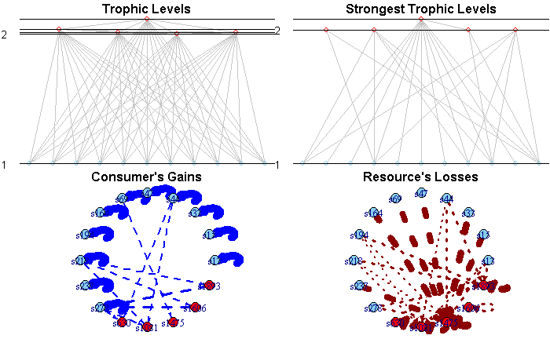

```r
toPostMortem(foodWebs[[examples[5]]], nodeSize = "None", threshold = thresholdEdges) -> temp
```

```r
temp
```

| from | to | effectPerUnit | effectActual | Type | effectEfficiency | effectNormalised |
| --- | --- | --- | --- | --- | --- | --- |
| s1081 | s1081 | -0.0906762948 | -0.69370193 | Intrisc- | 0.96969936 | 0.8947617 |
| s218 | s1081 | 0.0001588236 | 0.04276809 | Exploit+ | 0.11783477 | 0.2482666 |
| s278 | s1081 | 0.0001337197 | 0.04066111 | Exploit+ | 0.09920968 | 0.2360357 |
| s44 | s1081 | 0.0001773059 | 0.04036011 | Exploit+ | 0.13154723 | 0.2342884 |
| s13 | s13 | 0.3521072296 | 3.03022400 | Intrisc+ | 1.00000000 | 1.0000000 |
| s1893 | s13 | -0.0103629896 | -0.13677574 | Exploit- | 0.25002627 | 0.3884491 |
| s1475 | s13 | -0.0032291207 | -0.10698118 | Exploit- | 0.07790850 | 0.3038312 |
| s1081 | s13 | -0.0095743495 | -0.07324676 | Exploit- | 0.23099888 | 0.2080240 |
| s1475 | s1475 | -0.0753157447 | -2.49522010 | Intrisc- | 1.00000000 | 1.0000000 |
| s69 | s1475 | 0.0002599427 | 0.01962855 | Exploit+ | 0.11079715 | 0.2606169 |

[output cut: 37 more lines]

### Largest Assembled

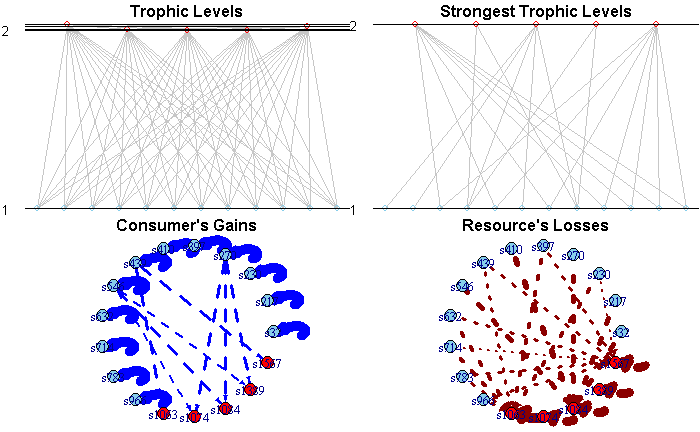

```r
toPostMortem(foodWebs[[examples[6]]], nodeSize = "None", threshold = thresholdEdges) -> temp
```

```r
temp
```

| from | to | effectPerUnit | effectActual | Type | effectEfficiency | effectNormalised |
| --- | --- | --- | --- | --- | --- | --- |
| s1063 | s1063 | -6.838267e-02 | -0.91947012 | Intrisc- | 1.00000000 | 1.0000000 |
| s439 | s1063 | 2.293504e-04 | 0.02234591 | Exploit+ | 0.09565029 | 0.3267774 |
| s1074 | s1074 | -8.841746e-02 | -0.29119236 | Intrisc- | 0.97782223 | 0.9125092 |
| s270 | s1074 | 7.367649e-05 | 0.03609562 | Exploit+ | 0.04322983 | 0.3102683 |
| s546 | s1074 | 6.303019e-05 | 0.03126393 | Exploit+ | 0.03698310 | 0.2687364 |
| s1084 | s1084 | -7.518463e-02 | -2.02682900 | Intrisc- | 0.94468277 | 0.9737787 |
| s546 | s1084 | 1.037928e-04 | 0.05148281 | Exploit+ | 0.08123706 | 0.3967486 |
| s270 | s1084 | 8.908105e-05 | 0.04364263 | Exploit+ | 0.06972238 | 0.3363288 |
| s1389 | s1389 | -8.368615e-02 | -0.59081832 | Intrisc- | 0.97009558 | 0.9469654 |
| s270 | s1389 | 8.311869e-05 | 0.04072155 | Exploit+ | 0.05195540 | 0.3487187 |

[output cut: 34 more lines]

### Largest Hybrid

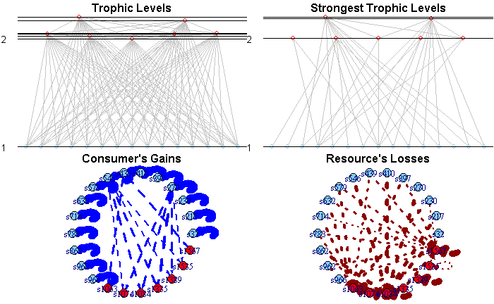

```r
toPostMortem(foodWebs[[examples[7]]], nodeSize = "None", threshold = thresholdEdges) -> temp
```

```r
temp
```

| from | to | effectPerUnit | effectActual | Type | effectEfficiency | effectNormalised |
| --- | --- | --- | --- | --- | --- | --- |
| s1063 | s1063 | -6.838267e-02 | -9.182781e-01 | Intrisc- | 1.00000000 | 1.0000000 |
| s439 | s1063 | 2.293504e-04 | 2.235780e-02 | Exploit+ | 0.06924851 | 0.3269430 |
| s1074 | s1074 | -8.841746e-02 | -2.875985e-01 | Intrisc- | 0.97608124 | 0.9115507 |
| s270 | s1074 | 7.367649e-05 | 3.616198e-02 | Exploit+ | 0.03207032 | 0.3109478 |
| s546 | s1074 | 6.303019e-05 | 3.137716e-02 | Exploit+ | 0.02743613 | 0.2698043 |
| s1084 | s1084 | -7.518463e-02 | -2.020679e+00 | Intrisc- | 0.93955499 | 0.9737069 |
| s546 | s1084 | 1.037928e-04 | 5.166927e-02 | Exploit+ | 0.06161406 | 0.3982049 |
| s270 | s1084 | 8.908105e-05 | 4.372286e-02 | Exploit+ | 0.05288078 | 0.3369635 |
| s270 | s1335 | 2.284462e-04 | 1.121262e-01 | Exploit+ | 0.13766983 | 0.4761845 |
| s1567 | s1335 | -4.249126e-03 | -6.233903e-02 | Exploit- | 0.04056359 | 0.4020289 |

[output cut: 51 more lines]

## Threshold = 0.3

```r
thresholdEdges <- 0.3
```

### Example LM 1

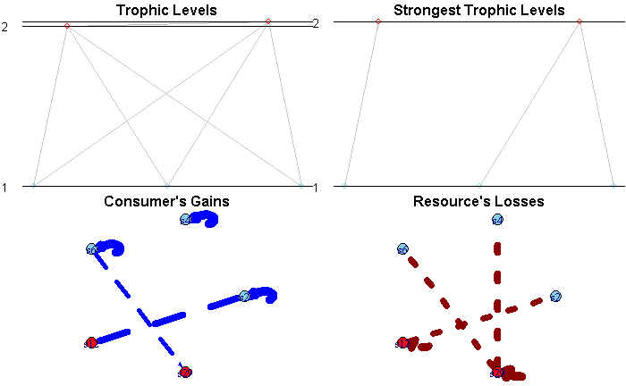

```r
toPostMortem(foodWebs[[examples[1]]], nodeSize = "None", threshold = thresholdEdges) -> temp
```

```r
temp
```

| from | to | effectPerUnit | effectActual | Type | effectEfficiency | effectNormalised |
| --- | --- | --- | --- | --- | --- | --- |
| s12 | s12 | -0.1066330280 | -2.15486367 | Intrisc- | 0.9499734 | 0.9531571 |
| s2 | s12 | 0.0002084357 | 0.15484385 | Exploit+ | 0.4841745 | 0.8574679 |
| s2 | s2 | 0.3082794145 | 229.01631827 | Intrisc+ | 1.0000000 | 1.0000000 |
| s12 | s2 | -0.0098070710 | -0.19818345 | Exploit- | 0.7702779 | 0.7118047 |
| s29 | s29 | -0.0942716513 | -1.77786427 | Intrisc- | 1.0000000 | 1.0000000 |
| s6 | s29 | 0.0002605935 | 0.04224961 | Exploit+ | 0.3065034 | 0.5119227 |
| s4 | s4 | 0.2118143576 | 17.06783849 | Intrisc+ | 1.0000000 | 1.0000000 |
| s29 | s4 | -0.0088792340 | -0.16745302 | Exploit- | 0.8804370 | 0.8417415 |
| s6 | s6 | 0.2135749758 | 34.62656907 | Intrisc+ | 1.0000000 | 1.0000000 |
| s29 | s6 | -0.0073551651 | -0.13871068 | Exploit- | 0.8921379 | 0.7699602 |

### Example LM 2

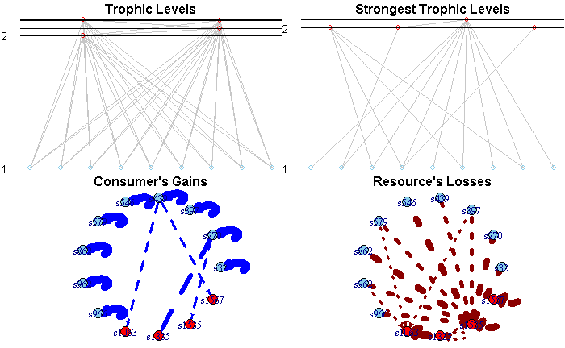

```r
toPostMortem(foodWebs[[examples[2]]], nodeSize = "None", threshold = thresholdEdges) -> temp
```

```r
temp
```

| from | to | effectPerUnit | effectActual | Type | effectEfficiency | effectNormalised |
| --- | --- | --- | --- | --- | --- | --- |
| s1063 | s1063 | -6.838267e-02 | -0.66649093 | Intrisc- | 1.00000000 | 1.0000000 |
| s439 | s1063 | 2.293504e-04 | 0.02478039 | Exploit+ | 0.13151183 | 0.3623783 |
| s270 | s1335 | 2.284462e-04 | 0.14698760 | Exploit+ | 0.21856504 | 0.6511578 |
| s1535 | s1335 | -1.392633e-03 | -0.07946316 | Exploit- | 0.01375336 | 0.3820492 |
| s1335 | s1335 | -9.117707e-02 | -0.07343636 | Intrisc- | 0.90044592 | 0.3530731 |
| s1535 | s1535 | -7.190290e-02 | -4.10275449 | Intrisc- | 0.97083024 | 0.9961165 |
| s270 | s1535 | 5.113308e-05 | 0.03290021 | Exploit+ | 0.04282004 | 0.3743002 |
| s1567 | s1567 | -7.492693e-02 | -0.20858970 | Intrisc- | 0.99563796 | 0.9848933 |
| s439 | s1567 | 2.858401e-04 | 0.03088388 | Exploit+ | 0.16840249 | 0.3953067 |
| s270 | s270 | 3.755309e-01 | 241.62534329 | Intrisc+ | 1.00000000 | 1.0000000 |

[output cut: 20 more lines]

### Invadable

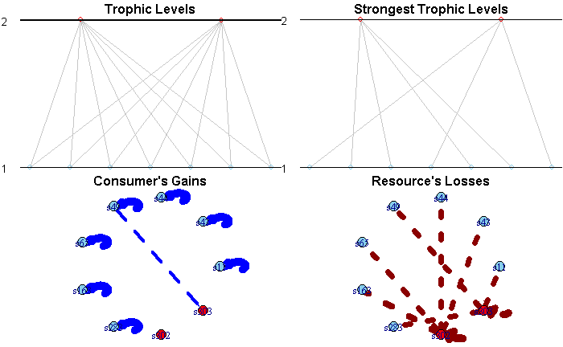

```r
toPostMortem(foodWebs[[examples[3]]], nodeSize = "None", threshold = thresholdEdges) -> temp
```

```r
temp
```

| from | to | effectPerUnit | effectActual | Type | effectEfficiency | effectNormalised |
| --- | --- | --- | --- | --- | --- | --- |
| s11 | s11 | 0.3391763332 | 58.90345426 | Intrisc+ | 1.0000000 | 1.0000000 |
| s303 | s11 | -0.0084245888 | -0.24387294 | Exploit- | 0.7201840 | 0.7647503 |
| s163 | s163 | 0.1883788831 | 6.10318987 | Intrisc+ | 1.0000000 | 1.0000000 |
| s302 | s163 | -0.0043024409 | -0.09226498 | Exploit- | 0.8882782 | 0.8501585 |
| s283 | s283 | 0.3307971683 | 81.78891026 | Intrisc+ | 1.0000000 | 1.0000000 |
| s303 | s283 | -0.0080517370 | -0.23307972 | Exploit- | 0.7150572 | 0.7546057 |
| s302 | s302 | -0.0836685802 | -1.79425584 | Intrisc- | 1.0000000 | 1.0000000 |
| s303 | s303 | -0.1029690242 | -2.98072218 | Intrisc- | 0.9711080 | 0.9784350 |
| s49 | s303 | 0.0001535383 | 0.06357629 | Exploit+ | 0.2323352 | 0.4401029 |
| s43 | s43 | 0.1726008175 | 20.38371675 | Intrisc+ | 1.0000000 | 1.0000000 |

[output cut: 7 more lines]

### Does Not Persist

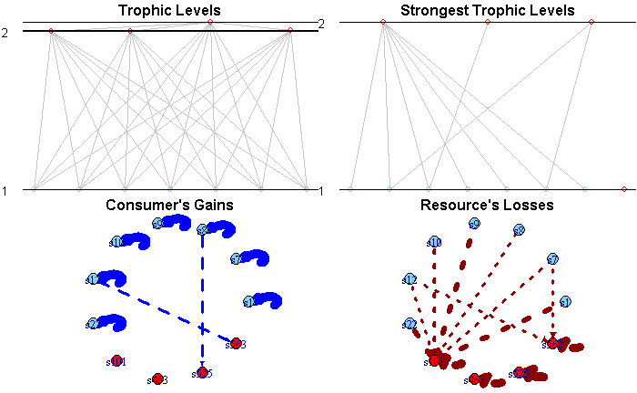

```r
toPostMortem(foodWebs[[examples[4]]], nodeSize = "None", threshold = thresholdEdges) -> temp
```

```r
temp
```

| from | to | effectPerUnit | effectActual | Type | effectEfficiency | effectNormalised |
| --- | --- | --- | --- | --- | --- | --- |
| s1 | s1 | 0.2725839862 | 62.82303871 | Intrisc+ | 1.0000000 | 1.0000000 |
| s101 | s1 | -0.0087721841 | -0.18070878 | Exploit- | 0.3747638 | 0.6631473 |
| s10 | s10 | 0.1839406971 | 11.24221329 | Intrisc+ | 1.0000000 | 1.0000000 |
| s101 | s10 | -0.0036224702 | -0.07462362 | Exploit- | 0.1589154 | 0.4056802 |
| s101 | s101 | -0.0773910168 | -1.59427069 | Intrisc- | 0.9550876 | 0.9894034 |
| s12 | s12 | 0.2337285480 | 20.44439103 | Intrisc+ | 1.0000000 | 1.0000000 |
| s101 | s12 | -0.0040726974 | -0.08389840 | Exploit- | 0.1495288 | 0.3589848 |
| s563 | s12 | -0.0087217563 | -0.07878879 | Exploit- | 0.3202186 | 0.3371218 |
| s22 | s22 | 0.2684283955 | 0.03279405 | Intrisc+ | 1.0000000 | 1.0000000 |
| s101 | s22 | -0.0105942437 | -0.21824357 | Exploit- | 0.4094774 | 0.6958047 |

[output cut: 12 more lines]

### Hybrid

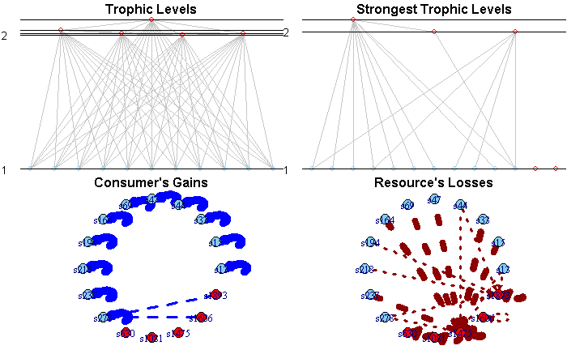

```r
toPostMortem(foodWebs[[examples[5]]], nodeSize = "None", threshold = thresholdEdges) -> temp
```

```r
temp
```

| from | to | effectPerUnit | effectActual | Type | effectEfficiency | effectNormalised |
| --- | --- | --- | --- | --- | --- | --- |
| s1081 | s1081 | -0.0906762948 | -0.69370193 | Intrisc- | 0.96969936 | 0.8947617 |
| s13 | s13 | 0.3521072296 | 3.03022400 | Intrisc+ | 1.00000000 | 1.0000000 |
| s1893 | s13 | -0.0103629896 | -0.13677574 | Exploit- | 0.25002627 | 0.3884491 |
| s1475 | s13 | -0.0032291207 | -0.10698118 | Exploit- | 0.07790850 | 0.3038312 |
| s1475 | s1475 | -0.0753157447 | -2.49522010 | Intrisc- | 1.00000000 | 1.0000000 |
| s15 | s15 | 0.1980433127 | 9.06634802 | Intrisc+ | 1.00000000 | 1.0000000 |
| s1475 | s15 | -0.0052838707 | -0.17505530 | Exploit- | 0.66877783 | 0.8839243 |
| s1475 | s1606 | -0.0022621317 | -0.07494471 | Exploit- | 0.02556479 | 0.5775924 |
| s1606 | s1606 | -0.0851626714 | -0.04792511 | Intrisc- | 0.96243984 | 0.3693547 |
| s278 | s1606 | 0.0001727719 | 0.05253599 | Exploit+ | 0.13856701 | 0.3146034 |

[output cut: 23 more lines]

### Largest Assembled

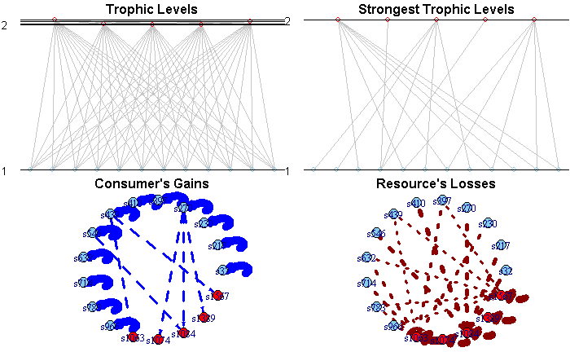

```r
toPostMortem(foodWebs[[examples[6]]], nodeSize = "None", threshold = thresholdEdges) -> temp
```

```r
temp
```

| from | to | effectPerUnit | effectActual | Type | effectEfficiency | effectNormalised |
| --- | --- | --- | --- | --- | --- | --- |
| s1063 | s1063 | -6.838267e-02 | -0.91947012 | Intrisc- | 1.00000000 | 1.0000000 |
| s439 | s1063 | 2.293504e-04 | 0.02234591 | Exploit+ | 0.09565029 | 0.3267774 |
| s1074 | s1074 | -8.841746e-02 | -0.29119236 | Intrisc- | 0.97782223 | 0.9125092 |
| s270 | s1074 | 7.367649e-05 | 0.03609562 | Exploit+ | 0.04322983 | 0.3102683 |
| s1084 | s1084 | -7.518463e-02 | -2.02682900 | Intrisc- | 0.94468277 | 0.9737787 |
| s546 | s1084 | 1.037928e-04 | 0.05148281 | Exploit+ | 0.08123706 | 0.3967486 |
| s270 | s1084 | 8.908105e-05 | 0.04364263 | Exploit+ | 0.06972238 | 0.3363288 |
| s1389 | s1389 | -8.368615e-02 | -0.59081832 | Intrisc- | 0.97009558 | 0.9469654 |
| s270 | s1389 | 8.311869e-05 | 0.04072155 | Exploit+ | 0.05195540 | 0.3487187 |
| s1567 | s1567 | -7.492693e-02 | -1.10050933 | Intrisc- | 0.99563796 | 0.9960053 |

[output cut: 30 more lines]

### Largest Hybrid

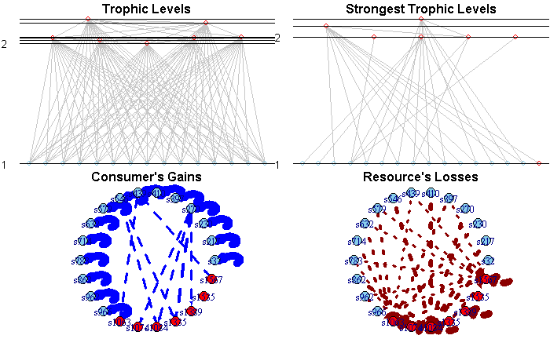

```r
toPostMortem(foodWebs[[examples[7]]], nodeSize = "None", threshold = thresholdEdges) -> temp
```

```r
temp
```

| from | to | effectPerUnit | effectActual | Type | effectEfficiency | effectNormalised |
| --- | --- | --- | --- | --- | --- | --- |
| s1063 | s1063 | -6.838267e-02 | -9.182781e-01 | Intrisc- | 1.00000000 | 1.0000000 |
| s439 | s1063 | 2.293504e-04 | 2.235780e-02 | Exploit+ | 0.06924851 | 0.3269430 |
| s1074 | s1074 | -8.841746e-02 | -2.875985e-01 | Intrisc- | 0.97608124 | 0.9115507 |
| s270 | s1074 | 7.367649e-05 | 3.616198e-02 | Exploit+ | 0.03207032 | 0.3109478 |
| s1084 | s1084 | -7.518463e-02 | -2.020679e+00 | Intrisc- | 0.93955499 | 0.9737069 |
| s546 | s1084 | 1.037928e-04 | 5.166927e-02 | Exploit+ | 0.06161406 | 0.3982049 |
| s270 | s1084 | 8.908105e-05 | 4.372286e-02 | Exploit+ | 0.05288078 | 0.3369635 |
| s270 | s1335 | 2.284462e-04 | 1.121262e-01 | Exploit+ | 0.13766983 | 0.4761845 |
| s1567 | s1335 | -4.249126e-03 | -6.233903e-02 | Exploit- | 0.04056359 | 0.4020289 |
| s1063 | s1335 | -4.438857e-03 | -5.960728e-02 | Exploit- | 0.04237482 | 0.3844117 |

[output cut: 43 more lines]

## Common Core

### Setup

```r
listintersect <- function(x) {
  while(length(x) > 1) {
    x <- c(list(intersect(x[[1]], x[[2]])), x[c(-1, -2)])
  }
  unlist(x)
}
```

```r
communityCores <- communitiesAll %>% dplyr::group_by(
  TotalID, DatasetID, CombnNum
) %>% dplyr::summarise(
  Core = toString(lapply(Communities, RMTRCode2::CsvRowSplit) %>% listintersect),
  All = toString(unique(RMTRCode2::CsvRowSplit(Communities))),
  FractionCore = length(RMTRCode2::CsvRowSplit(Core)) / length(RMTRCode2::CsvRowSplit(All)),
  CountRows = n(),
  CountRowsUnique = length(unique(Communities)),
  .groups = "drop"
) %>% dplyr::mutate(
  CommunityAbund = "",
  CorePresentAfterPersist = ""
)
```

First, do the cores persist? (Clearly, they are invadable, so we can skip that.)

```r
for (r in 1:nrow(communityCores)) {
  temp <- with(
    communityCores[r, ],
    {
      temp <- RMTRCode2::CsvRowSplit(Core)
      RMTRCode2::LawMorton1996_NumIntegration(
        A = mats[[DatasetID]][[CombnNum]][temp, temp],
        R = pools[[DatasetID]][[CombnNum]]$ReproductionRate[temp],
        X = ifelse(pools[[DatasetID]][[CombnNum]]$Type[temp] == "Basal", 1000, 10),
        OuterTimeStepSize = 3E4,
        Tolerance = 1E-6
      ) # retrieve the abundance over time matrix
    }
  )

  temp <- temp[nrow(temp), -1] # choose last row, remove time column.

  communityCores$CorePresentAfterPersist[r] <- toString(
    RMTRCode2::CsvRowSplit(communityCores$Core[r])[which(temp > 1E-6)]
  )

  temp <- temp[which(temp > 1E-6)] # remove microfoxes.

  communityCores$CommunityAbund[r] <- toString(temp)
}
```

```r
communityCores %>% dplyr::group_by(TotalID) %>% dplyr::mutate(
  FractionPersists = length(RMTRCode2::CsvRowSplit(CorePresentAfterPersist)) / length(RMTRCode2::CsvRowSplit(Core))
)
```

| TotalID | DatasetID | CombnNum | Core | All | FractionCore | CountRows | CountRowsUnique | CommunityAbund | CorePresentAfterPersist | FractionPersists |
| --- | --- | --- | --- | --- | --- | --- | --- | --- | --- | --- |
| 14 1 | 1 | 14 | 5, 6 | 5, 6, 35, 38, 37, 59, 7, 60 | 0.2500000 | 8 | 5 | 1079.81713365001, 7284.56806253026 | 5, 6 | 1.0000000 |
| 14 2 | 2 | 14 | 2, 3, 9, 10 | 2, 3, 9, 10, 31, 58, 48, 51 | 0.5000000 | 2 | 2 | 1046.19611329949, 1351.98257616524, 5638.5740269556, 7185.23304010676 | 2, 3, 9, 10 | 1.0000000 |
| 17 2 | 2 | 17 | 68, 98, 108, 112, 151, 172, 339 | 11, 68, 98, 108, 112, 151, 166, 172, 269, 331, 339, 348, 351, 95, 113, 350, 358 | 0.4117647 | 8 | 5 | 40.1167932999784, 99.8947503499552, 107.078545887636, 9435.43380637117, 8.10354982529082, 23.0323723374259 | 68, 98, 108, 151, 172, 339 | 0.8571429 |
| 19 1 | 1 | 19 | 1, 2, 3, 141 | 1, 2, 3, 14, 52, 141, 68, 15 | 0.5000000 | 13 | 6 | 814.955417570584, 725.486056235265, 165.494642413023 | 2, 3, 141 | 0.7500000 |
| 2 3 | 3 | 2 | 2, 4, 6, 29 | 2, 4, 6, 12, 29, 13 | 0.6666667 | 3 | 2 | 5756.85735119513, 37.661798938306 | 2, 29 | 0.5000000 |
| 20 1 | 1 | 20 | 1, 4, 6, 103 | 1, 4, 6, 103, 131, 162 | 0.6666667 | 5 | 3 | 3852.86053770276, 48.6092468665191 | 6, 103 | 0.5000000 |
| 20 2 | 2 | 20 | 2, 9, 10, 150, 194 | 2, 9, 10, 137, 150, 194, 20 | 0.7142857 | 2 | 2 | 7.31189554088311, 269.531217784375, 521.745473674132, 18.8839950693456, 19.1295129830543 | 2, 9, 10, 150, 194 | 1.0000000 |
| 26 1 | 1 | 26 | 1, 7, 10, 41 | 1, 7, 10, 41, 471, 598 | 0.6666667 | 2 | 2 | 291.967699857725, 61.9003444612631, 52.0393654021275 | 7, 10, 41 | 0.7500000 |
| 26 2 | 2 | 26 | 3, 5, 10 | 3, 5, 10, 125, 404, 86, 186 | 0.4285714 | 7 | 3 | 910.735891262282, 9061.7167849935, 1209.52041741011 | 3, 5, 10 | 1.0000000 |
| 27 2 | 2 | 27 | 1, 8, 9, 10, 12, 101, 463, 563 | 1, 7, 8, 9, 10, 12, 101, 463, 525, 563, 22 | 0.7272727 | 6 | 3 | 1.68620456903342, 66.6771360707298, 355.937602965119, 43.3405570528928, 87.2981573613646, 0.000993446868738611, 27.3957017597797, 10.5660322064164 | 1, 8, 9, 10, 12, 101, 463, 563 | 1.0000000 |

[output cut: 7 more lines]

Most of the cores persist as they are, but a few of them contract. Some of this might be because of things in the core that do not belong there. These species are present anyways due to insufficiently many communities sampled to rule them out. Perhaps concerning are the cases where there are only two species present.

Let’s see what these cores look like in contrast to the full systems.

```r
foodWebCores <- list()

for (r in 1:nrow(communityCores)) {
  foodWebCores[[r]] <- with(
    communityCores[r, ],
    {
      redCom <- RMTRCode2::CsvRowSplit(CorePresentAfterPersist)
      redMat <- as.matrix(mats[[DatasetID]][[CombnNum]][redCom, redCom])
      # Note: should be a matrix, but will error if single entry.
      redPool <- pools[[DatasetID]][[CombnNum]][redCom, ]

      colnames(redMat) <- paste0('s',as.character(redCom))
      rownames(redMat) <- colnames(redMat)

      names(redPool)[1] <- "node"
      redPool$node <- colnames(redMat)
      names(redPool)[3] <- "M"

      Graph <- igraph::graph_from_adjacency_matrix(
        redMat, weighted = TRUE
      )

      Graph <- igraph::set.vertex.attribute(
        Graph, "name", value = colnames(redMat)
      )

      redPool$N <- RMTRCode2::CsvRowSplit(CommunityAbund)

      # For later analysis, take the matrix diagonal.

      redPool$Intraspecific <- diag(redMat)

      GraphAsDataFrame <- igraph::as_data_frame(Graph)

      # Add in abundances for calculating abundance * (gain or loss)
      GraphAsDataFrame <- dplyr::left_join(
        GraphAsDataFrame,
        dplyr::select(redPool, node, N),
        by = c("to" = "node")
      )

      # Split data frame.
      ResCon <- GraphAsDataFrame[GraphAsDataFrame$weight > 0,]
      ConRes <- GraphAsDataFrame[GraphAsDataFrame$weight < 0,]

      # Reorder and rename variables.
      ResCon <- dplyr::select(ResCon,
                                 to, from, # resource = to, consumer = from,
                                 effectPerUnit = weight, resourceAbund = N)
      ConRes <- dplyr::select(ConRes,
                                 to, from, # resource = from, consumer = to,
                                 effectPerUnit = weight, consumerAbund = N)
      ResCon <- dplyr::mutate(dplyr::group_by(ResCon, from),
                              effectActual = effectPerUnit * resourceAbund,
                              Type = "Exploit+")
      ConRes <- dplyr::mutate(dplyr::group_by(ConRes, from),
                              effectActual = effectPerUnit * consumerAbund,
                              Type = ifelse(from == to,
                                            "SelfReg-",
                                            "Exploit-"))

      IntriG <- with(redPool, data.frame(
                              from = node, #resource = node,
                              to = node, #consumer = node,
                              effectPerUnit = ifelse(ReproductionRate > 0,
                                                   ReproductionRate, 0),
                              effectActual = ifelse(ReproductionRate > 0,
                                                  N * ReproductionRate, 0),
                              Type = "Intrisc+"))
      IntriL <- with(redPool, data.frame(
                              from = node, #resource = node,
                              to = node, #consumer = node,
                              effectPerUnit = ifelse(ReproductionRate < 0,
                                                   ReproductionRate, 0),
                              effectActual = ifelse(ReproductionRate < 0,
                                                  N * ReproductionRate, 0),
                              Type = "Intrisc-"))

      EdgeDataFrame <- dplyr::bind_rows(
        dplyr::select(ResCon, -resourceAbund),
        dplyr::select(ConRes, -consumerAbund),
        IntriG, IntriL
      )

      EdgeDataFrame <- EdgeDataFrame %>% dplyr::rename(
        # Empirically speaking, to and from appear reversed.
        # A consumer (from) should have a negative effect on resource (to),
        # but the organisation so far marks it as positive. We fix this.
        tempname = to,
        to = from
      ) %>% dplyr::rename(
        from = tempname
      ) %>% dplyr::filter(
        # Remove placeholder entries
        effectPerUnit != 0
      ) %>% dplyr::mutate(
        # Useful to keep effects separate
        effectSign = sign(effectPerUnit)
      ) %>% group_by(
        to, effectSign
      ) %>% dplyr::mutate(
        # Perform the post mortem of the most influential from's
        effectEfficiency = effectPerUnit / sum(effectPerUnit),
        effectNormalised = effectActual / sum(effectActual)
      ) %>% dplyr::arrange(to)

      list(
        Edges = EdgeDataFrame,
        Vertices = redPool
      )
    }
  )
}
```

### Example LM 1

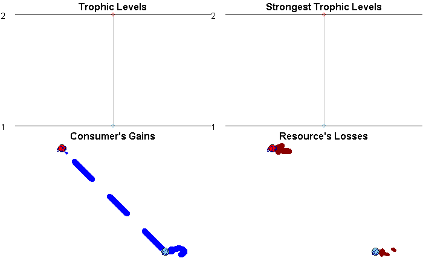

```r
toPostMortem(foodWebCores[[which(communityCores$TotalID == communitiesAll$TotalID[examples[1]])]], nodeSize = "None", threshold = "Adaptive") -> temp
```

```r
temp
```

| from | to | effectPerUnit | effectActual | Type | effectEfficiency | effectNormalised |
| --- | --- | --- | --- | --- | --- | --- |
| s2 | s2 | 3.082794e-01 | 1774.72061336 | Intrisc+ | 1.0000000 | 1.0000000 |
| s2 | s2 | -3.464238e-05 | -0.19943126 | SelfReg- | 0.0118444 | 0.6469172 |
| s2 | s29 | 1.637554e-05 | 0.09427165 | Exploit+ | 1.0000000 | 1.0000000 |
| s29 | s29 | -9.427165e-02 | -3.55043998 | Intrisc- | 1.0000000 | 1.0000000 |

### Example LM 2 and Largest

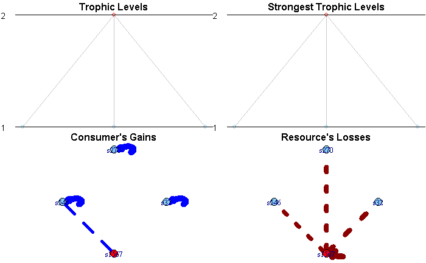

```r
toPostMortem(foodWebCores[[which(communityCores$TotalID == communitiesAll$TotalID[examples[2]])]], nodeSize = "None", threshold = "Adaptive") -> temp
```

```r
temp
```

| from | to | effectPerUnit | effectActual | Type | effectEfficiency | effectNormalised |
| --- | --- | --- | --- | --- | --- | --- |
| s1567 | s1567 | -7.492693e-02 | -6.97886114 | Intrisc- | 1.0000000 | 1.0000000 |
| s546 | s1567 | 1.735927e-05 | 0.04440241 | Exploit+ | 0.2870511 | 0.5926096 |
| s270 | s270 | 3.755309e-01 | 396.69071954 | Intrisc+ | 1.0000000 | 1.0000000 |
| s1567 | s270 | -3.537670e-03 | -0.32950652 | Exploit- | 0.9878340 | 0.8774417 |
| s32 | s32 | 3.472899e-01 | 126.75916379 | Intrisc+ | 1.0000000 | 1.0000000 |
| s1567 | s32 | -3.575955e-03 | -0.33307244 | Exploit- | 0.9892245 | 0.9590617 |
| s546 | s546 | 3.957105e-01 | 1012.16840543 | Intrisc+ | 1.0000000 | 1.0000000 |
| s1567 | s546 | -3.058948e-03 | -0.28491723 | Exploit- | 0.9860376 | 0.7200142 |

### Invadable

```r
# which(communityCores$TotalID == communitiesAll$TotalID[examples[3]])
#toPostMortem(foodWebCores[[14]], nodeSize = "None", threshold = "Adaptive") -> temp
```

```r
#temp
foodWebCores[[which(communityCores$TotalID == communitiesAll$TotalID[examples[3]])]]
```

| from | to | effectPerUnit | effectActual | Type | effectSign | effectEfficiency | effectNormalised |
| --- | --- | --- | --- | --- | --- | --- | --- |
| s11 | s11 | -3.169962e-05 | -0.008803075 | SelfReg- | -1 | 0.002709872 | 0.02595427 |
| s302 | s11 | -3.241539e-03 | -0.123563313 | Exploit- | -1 | 0.277106093 | 0.36430405 |
| s303 | s11 | -8.424589e-03 | -0.206809945 | Exploit- | -1 | 0.720184035 | 0.60974167 |
| s11 | s11 | 3.391763e-01 | 94.190244146 | Intrisc+ | 1 | 1.000000000 | 1.00000000 |
| s163 | s163 | -1.730750e-04 | -0.015340141 | SelfReg- | -1 | 0.035732905 | 0.08143238 |
| s302 | s163 | -4.302441e-03 | -0.164003518 | Exploit- | -1 | 0.888278171 | 0.87060458 |
| s303 | s163 | -3.680580e-04 | -0.009035224 | Exploit- | -1 | 0.075988923 | 0.04796304 |
| s163 | s163 | 1.883789e-01 | 16.696572041 | Intrisc+ | 1 | 1.000000000 | 1.00000000 |
| s283 | s283 | -3.095668e-05 | -0.012015024 | SelfReg- | -1 | 0.002749195 | 0.03632142 |
| s302 | s283 | -3.177576e-03 | -0.121125104 | Exploit- | -1 | 0.282193582 | 0.36616125 |

[output cut: 24 more lines]

|  | node | Type | M | ReproductionRate | N | Intraspecific |
| --- | --- | --- | --- | --- | --- | --- |
| 11 | s11 | Basal | 0.01017358 | 0.33917633 | 277.70288 | -3.169962e-05 |
| 43 | s43 | Basal | 0.09976333 | 0.17260082 | 136.57594 | -1.517362e-04 |
| 49 | s49 | Basal | 0.01001725 | 0.37050821 | 743.91710 | -4.020640e-05 |
| 163 | s163 | Basal | 0.09704279 | 0.18837888 | 88.63293 | -1.730750e-04 |
| 283 | s283 | Basal | 0.01002901 | 0.33079717 | 388.12381 | -3.095668e-05 |
| 302 | s302 | Consumer | 0.33876309 | -0.08366858 | 38.11871 | 0.000000e+00 |
| 303 | s303 | Consumer | 0.11897527 | -0.10296902 | 24.54837 | 0.000000e+00 |

```
NA
```

### Does Not Persist

```r
# which(communityCores$TotalID == communitiesAll$TotalID[examples[4]])
#toPostMortem(foodWebCores[[4]], nodeSize = "None", threshold = "Adaptive") -> temp
```

```r
foodWebCores[[which(communityCores$TotalID == communitiesAll$TotalID[examples[4]])]]
```

| from | to | effectPerUnit | effectActual | Type | effectSign | effectEfficiency | effectNormalised |
| --- | --- | --- | --- | --- | --- | --- | --- |
| s1 | s1 | -3.587819e-05 | -6.049797e-05 | SelfReg- | -1 | 0.001625539 | 2.219391e-04 |
| s101 | s1 | -8.772184e-03 | -8.714699e-06 | Exploit- | -1 | 0.397442748 | 3.197021e-05 |
| s463 | s1 | -7.865650e-03 | -2.154850e-01 | Exploit- | -1 | 0.356370277 | 7.905150e-01 |
| s563 | s1 | -5.397854e-03 | -5.703390e-02 | Exploit- | -1 | 0.244561436 | 2.092311e-01 |
| s1 | s1 | 2.725840e-01 | 4.596324e-01 | Intrisc+ | 1 | 1.000000000 | 1.000000e+00 |
| s10 | s10 | -1.667152e-04 | -7.225530e-03 | SelfReg- | -1 | 0.012478875 | 3.928184e-02 |
| s101 | s10 | -3.622470e-03 | -3.598732e-06 | Exploit- | -1 | 0.271147156 | 1.956463e-05 |
| s463 | s10 | -4.491367e-03 | -1.230441e-01 | Exploit- | -1 | 0.336185314 | 6.689337e-01 |
| s563 | s10 | -5.079242e-03 | -5.366744e-02 | Exploit- | -1 | 0.380188655 | 2.917649e-01 |
| s10 | s10 | 1.839407e-01 | 7.972092e+00 | Intrisc+ | 1 | 1.000000000 | 1.000000e+00 |

[output cut: 39 more lines]

|  | node | Type | M | ReproductionRate | N | Intraspecific |
| --- | --- | --- | --- | --- | --- | --- |
| 1 | s1 | Basal | 0.01503578 | 0.27258399 | 1.686205e+00 | -3.587819e-05 |
| 8 | s8 | Basal | 0.09263399 | 0.19024469 | 6.667714e+01 | -1.787267e-04 |
| 9 | s9 | Basal | 0.01752378 | 0.29045021 | 3.559376e+02 | -4.870933e-05 |
| 10 | s10 | Basal | 0.08507756 | 0.18394070 | 4.334056e+01 | -1.667152e-04 |
| 12 | s12 | Basal | 0.07913308 | 0.23372855 | 8.729816e+01 | -1.888611e-04 |
| 101 | s101 | Consumer | 0.25288871 | -0.07739102 | 9.934469e-04 | 0.000000e+00 |
| 463 | s463 | Consumer | 0.32131438 | -0.07201824 | 2.739570e+01 | 0.000000e+00 |
| 563 | s563 | Consumer | 0.37500450 | -0.08521230 | 1.056603e+01 | 0.000000e+00 |

```
NA
```

### Hybrid

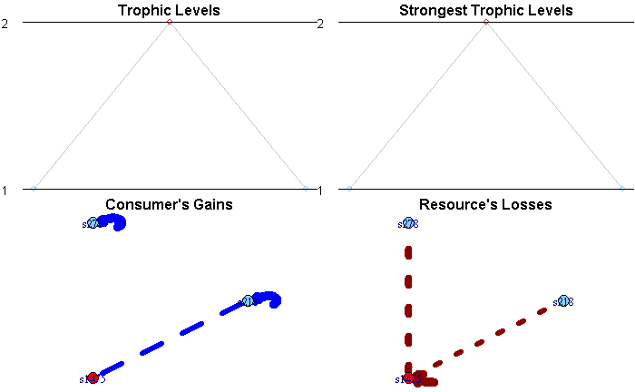

```r
toPostMortem(foodWebCores[[which(communityCores$TotalID == communitiesAll$TotalID[examples[5]])]], nodeSize = "None", threshold = "Adaptive") -> temp
```

```r
temp
```

| from | to | effectPerUnit | effectActual | Type | effectEfficiency | effectNormalised |
| --- | --- | --- | --- | --- | --- | --- |
| s1475 | s1475 | -7.531574e-02 | -6.63358214 | Intrisc- | 1.0000000 | 1.0000000 |
| s218 | s1475 | 1.464494e-05 | 0.04571213 | Exploit+ | 0.4034851 | 0.6069398 |
| s218 | s218 | 3.482934e-01 | 1087.14909307 | Intrisc+ | 1.0000000 | 1.0000000 |
| s1475 | s218 | -2.603341e-03 | -0.22929439 | Exploit- | 0.9855671 | 0.6583369 |
| s278 | s278 | 3.659613e-01 | 500.37835621 | Intrisc+ | 1.0000000 | 1.0000000 |
| s1475 | s278 | -3.559924e-03 | -0.31354726 | Exploit- | 0.9893465 | 0.8567772 |

## Adaptive Core

### Example LM 1

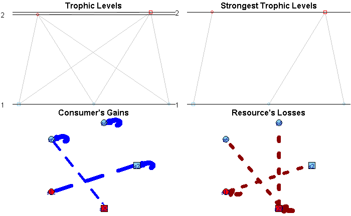

```r
foodWebs[[examples[1]]]$Vertices$Core <- foodWebs[[examples[1]]]$Vertices$node %in% foodWebCores[[which(communityCores$TotalID == communitiesAll$TotalID[examples[1]])]]$Vertices$node
toPostMortem(foodWebs[[examples[1]]], nodeSize = "None", threshold = "Adaptive") -> temp
```

```r
temp
```

| from | to | effectPerUnit | effectActual | Type | effectEfficiency | effectNormalised |
| --- | --- | --- | --- | --- | --- | --- |
| s12 | s12 | -0.1066330280 | -2.15486367 | Intrisc- | 0.9499734 | 0.9531571 |
| s2 | s12 | 0.0002084357 | 0.15484385 | Exploit+ | 0.4841745 | 0.8574679 |
| s2 | s2 | 0.3082794145 | 229.01631827 | Intrisc+ | 1.0000000 | 1.0000000 |
| s12 | s2 | -0.0098070710 | -0.19818345 | Exploit- | 0.7702779 | 0.7118047 |
| s29 | s29 | -0.0942716513 | -1.77786427 | Intrisc- | 1.0000000 | 1.0000000 |
| s6 | s29 | 0.0002605935 | 0.04224961 | Exploit+ | 0.3065034 | 0.5119227 |
| s4 | s4 | 0.2118143576 | 17.06783849 | Intrisc+ | 1.0000000 | 1.0000000 |
| s29 | s4 | -0.0088792340 | -0.16745302 | Exploit- | 0.8804370 | 0.8417415 |
| s6 | s6 | 0.2135749758 | 34.62656907 | Intrisc+ | 1.0000000 | 1.0000000 |
| s29 | s6 | -0.0073551651 | -0.13871068 | Exploit- | 0.8921379 | 0.7699602 |